# Assignment 4

2021-10-23

## Introduction

In this exercise, a dataset was used in order to get practice with calculating risk and odds ratios. These data were also used to examine vaccine efficacy.

## Method

The data for these questions were provided by the exercise prompt for the course, which were in turn obtained from Reference 1 (Eichner, 2001).

The data were organized and analyzed completely in `R`. The course literature referred to methods in Excel and other third-party tools, but I selected to do everything in `R` since third-party tools may not be open-source or stable in the future.

### Loading the data

#### Instructions:

Use Year, Vaccine Coverage%, n, and observed number of cases for both unvaccinated and vaccinated.

#### Instructions:

Using vaccine coverage and n, you should be able to calculate the total number of individuals in each group; unvaccinated and vaccinated for all cohorts.

```r
measles %<>%
    mutate(
        nVac = round(n * (pCentCvg / 100), 0)
        , nUnvac = n - nVac)
measles
```

```
## # A tibble: 14 x 7
##     Year pCentCvg     n obsUnvac obsVac  nVac nUnvac
##    <int>    <dbl> <dbl>    <dbl>  <dbl> <dbl>  <dbl>
##  1  1973     45.1  1253        3      2   565    688
##  2  1974     27.6  1509        3      2   416   1093
##  3  1975     42.4  1548        9      7   656    892
##  4  1976     35.7  1690        7      3   603   1087
##  5  1977     43.7  1747       20      5   763    984
##  6  1978     54.2  1871       22      6  1014    857
##  7  1979     67.7  1810       17      7  1225    585
##  8  1980     66.8  1903       17      4  1271    632
##  9  1981     72.6  2027       22      3  1472    555
## 10  1982     74.3  2020       24      4  1501    519
## 11  1983     73.7  2076       15      6  1530    546
## 12  1984     79.6  2081       18      7  1656    425
## 13  1985     83.7  2089       20      6  1748    341
## 14  1986     85    2147       16      7  1825    322
```

#### Instructions:

Calculate the risk for contracting measles for both groups for all cohorts.

```r
measles %<>%
    mutate(riskVac = obsVac / nVac
           , riskUnvac = obsUnvac / nUnvac)
measles
```

```
## # A tibble: 14 x 9
##     Year pCentCvg     n obsUnvac obsVac  nVac nUnvac riskVac riskUnvac
##    <int>    <dbl> <dbl>    <dbl>  <dbl> <dbl>  <dbl>   <dbl>     <dbl>
##  1  1973     45.1  1253        3      2   565    688 0.00354   0.00436
##  2  1974     27.6  1509        3      2   416   1093 0.00481   0.00274
##  3  1975     42.4  1548        9      7   656    892 0.0107    0.0101
##  4  1976     35.7  1690        7      3   603   1087 0.00498   0.00644
##  5  1977     43.7  1747       20      5   763    984 0.00655   0.0203
##  6  1978     54.2  1871       22      6  1014    857 0.00592   0.0257
##  7  1979     67.7  1810       17      7  1225    585 0.00571   0.0291
##  8  1980     66.8  1903       17      4  1271    632 0.00315   0.0269
##  9  1981     72.6  2027       22      3  1472    555 0.00204   0.0396
## 10  1982     74.3  2020       24      4  1501    519 0.00266   0.0462
## 11  1983     73.7  2076       15      6  1530    546 0.00392   0.0275
## 12  1984     79.6  2081       18      7  1656    425 0.00423   0.0424
## 13  1985     83.7  2089       20      6  1748    341 0.00343   0.0587
## 14  1986     85    2147       16      7  1825    322 0.00384   0.0497
```

#### Instructions:

Calculate the odds.

```r
measles %<>%
    mutate(oddsVac = riskVac / (1 - riskVac)
           , oddsUnvac = riskUnvac / (1 - riskUnvac))
measles
```

```
## # A tibble: 14 x 11
##     Year pCentCvg     n obsUnvac obsVac  nVac nUnvac riskVac riskUnvac oddsVac
##    <int>    <dbl> <dbl>    <dbl>  <dbl> <dbl>  <dbl>   <dbl>     <dbl>   <dbl>
##  1  1973     45.1  1253        3      2   565    688 0.00354   0.00436 0.00355
##  2  1974     27.6  1509        3      2   416   1093 0.00481   0.00274 0.00483
##  3  1975     42.4  1548        9      7   656    892 0.0107    0.0101  0.0108
##  4  1976     35.7  1690        7      3   603   1087 0.00498   0.00644 0.005
##  5  1977     43.7  1747       20      5   763    984 0.00655   0.0203  0.00660
##  6  1978     54.2  1871       22      6  1014    857 0.00592   0.0257  0.00595
##  7  1979     67.7  1810       17      7  1225    585 0.00571   0.0291  0.00575
##  8  1980     66.8  1903       17      4  1271    632 0.00315   0.0269  0.00316
##  9  1981     72.6  2027       22      3  1472    555 0.00204   0.0396  0.00204
## 10  1982     74.3  2020       24      4  1501    519 0.00266   0.0462  0.00267
## 11  1983     73.7  2076       15      6  1530    546 0.00392   0.0275  0.00394
## 12  1984     79.6  2081       18      7  1656    425 0.00423   0.0424  0.00424
## 13  1985     83.7  2089       20      6  1748    341 0.00343   0.0587  0.00344
## 14  1986     85    2147       16      7  1825    322 0.00384   0.0497  0.00385
## # ... with 1 more variable: oddsUnvac <dbl>
```

#### Instructions:

Calculate the risk ratio (RR) and odds ratio (OR) for all cohorts.

```r
measles %<>%
    mutate(riskRatio = riskVac / riskUnvac)
measles
```

```
## # A tibble: 14 x 12
##     Year pCentCvg     n obsUnvac obsVac  nVac nUnvac riskVac riskUnvac oddsVac
##    <int>    <dbl> <dbl>    <dbl>  <dbl> <dbl>  <dbl>   <dbl>     <dbl>   <dbl>
##  1  1973     45.1  1253        3      2   565    688 0.00354   0.00436 0.00355
##  2  1974     27.6  1509        3      2   416   1093 0.00481   0.00274 0.00483
##  3  1975     42.4  1548        9      7   656    892 0.0107    0.0101  0.0108
##  4  1976     35.7  1690        7      3   603   1087 0.00498   0.00644 0.005
##  5  1977     43.7  1747       20      5   763    984 0.00655   0.0203  0.00660
##  6  1978     54.2  1871       22      6  1014    857 0.00592   0.0257  0.00595
##  7  1979     67.7  1810       17      7  1225    585 0.00571   0.0291  0.00575
##  8  1980     66.8  1903       17      4  1271    632 0.00315   0.0269  0.00316
##  9  1981     72.6  2027       22      3  1472    555 0.00204   0.0396  0.00204
## 10  1982     74.3  2020       24      4  1501    519 0.00266   0.0462  0.00267
## 11  1983     73.7  2076       15      6  1530    546 0.00392   0.0275  0.00394
## 12  1984     79.6  2081       18      7  1656    425 0.00423   0.0424  0.00424
## 13  1985     83.7  2089       20      6  1748    341 0.00343   0.0587  0.00344
## 14  1986     85    2147       16      7  1825    322 0.00384   0.0497  0.00385
## # ... with 2 more variables: oddsUnvac <dbl>, riskRatio <dbl>
```

#### Instructions:

Calculate the vaccine efficacy for all cohorts.

```r
measles %<>%
    mutate(vacEff = 1 - riskRatio)
measles
```

```
## # A tibble: 14 x 13
##     Year pCentCvg     n obsUnvac obsVac  nVac nUnvac riskVac riskUnvac oddsVac
##    <int>    <dbl> <dbl>    <dbl>  <dbl> <dbl>  <dbl>   <dbl>     <dbl>   <dbl>
##  1  1973     45.1  1253        3      2   565    688 0.00354   0.00436 0.00355
##  2  1974     27.6  1509        3      2   416   1093 0.00481   0.00274 0.00483
##  3  1975     42.4  1548        9      7   656    892 0.0107    0.0101  0.0108
##  4  1976     35.7  1690        7      3   603   1087 0.00498   0.00644 0.005
##  5  1977     43.7  1747       20      5   763    984 0.00655   0.0203  0.00660
##  6  1978     54.2  1871       22      6  1014    857 0.00592   0.0257  0.00595
##  7  1979     67.7  1810       17      7  1225    585 0.00571   0.0291  0.00575
##  8  1980     66.8  1903       17      4  1271    632 0.00315   0.0269  0.00316
##  9  1981     72.6  2027       22      3  1472    555 0.00204   0.0396  0.00204
## 10  1982     74.3  2020       24      4  1501    519 0.00266   0.0462  0.00267
## 11  1983     73.7  2076       15      6  1530    546 0.00392   0.0275  0.00394
## 12  1984     79.6  2081       18      7  1656    425 0.00423   0.0424  0.00424
## 13  1985     83.7  2089       20      6  1748    341 0.00343   0.0587  0.00344
## 14  1986     85    2147       16      7  1825    322 0.00384   0.0497  0.00385
## # ... with 3 more variables: oddsUnvac <dbl>, riskRatio <dbl>, vacEff <dbl>
```

#### Instructions:

Perform a Chi2-test for the risk estimations for each cohort by analyzing 2x2-tables. Apply the Chi2 statistics when appropriate other wise use Fisher’s exact test.

```r
measles %<>%
    mutate(healthyUnvac = nUnvac - obsUnvac
           , healthyVac = nVac - obsVac)
measles
```

```
## # A tibble: 14 x 15
##     Year pCentCvg     n obsUnvac obsVac  nVac nUnvac riskVac riskUnvac oddsVac
##    <int>    <dbl> <dbl>    <dbl>  <dbl> <dbl>  <dbl>   <dbl>     <dbl>   <dbl>
##  1  1973     45.1  1253        3      2   565    688 0.00354   0.00436 0.00355
##  2  1974     27.6  1509        3      2   416   1093 0.00481   0.00274 0.00483
##  3  1975     42.4  1548        9      7   656    892 0.0107    0.0101  0.0108
##  4  1976     35.7  1690        7      3   603   1087 0.00498   0.00644 0.005
##  5  1977     43.7  1747       20      5   763    984 0.00655   0.0203  0.00660
##  6  1978     54.2  1871       22      6  1014    857 0.00592   0.0257  0.00595
##  7  1979     67.7  1810       17      7  1225    585 0.00571   0.0291  0.00575
##  8  1980     66.8  1903       17      4  1271    632 0.00315   0.0269  0.00316
##  9  1981     72.6  2027       22      3  1472    555 0.00204   0.0396  0.00204
## 10  1982     74.3  2020       24      4  1501    519 0.00266   0.0462  0.00267
## 11  1983     73.7  2076       15      6  1530    546 0.00392   0.0275  0.00394
## 12  1984     79.6  2081       18      7  1656    425 0.00423   0.0424  0.00424
## 13  1985     83.7  2089       20      6  1748    341 0.00343   0.0587  0.00344
## 14  1986     85    2147       16      7  1825    322 0.00384   0.0497  0.00385
## # ... with 5 more variables: oddsUnvac <dbl>, riskRatio <dbl>, vacEff <dbl>,
## #   healthyUnvac <dbl>, healthyVac <dbl>
```

```r
for (row in seq(nrow(measles))) {
    year <- measles$Year[row]
    tmpMatrix <-
        measles %>%
            select(obsVac, healthyVac, obsUnvac, healthyUnvac) %>%
            .[row, ] %>%
            unlist() %>%
            matrix(., 2, 2, byrow = TRUE)

    dimnames(tmpMatrix) <-
        list("Vaccination status"=c("1", "2"), "Disease Status"=c("1", "2"))

        assign(paste0('contingencyTableFor', year), tmpMatrix
               , envir = parent.frame())

    cat('\n\nFisher test for ', year, ':\n')
    print(fisher.test(tmpMatrix))

    rm(tmpMatrix)

}
```

```
##
##
## Fisher test for  1973 :
##
##  Fisher's Exact Test for Count Data
##
## data:  tmpMatrix
## p-value = 1
## alternative hypothesis: true odds ratio is not equal to 1
## 95 percent confidence interval:
##  0.06757195 7.10775137
## sample estimates:
## odds ratio
##  0.8112652
##
##
##
## Fisher test for  1974 :
##
##  Fisher's Exact Test for Count Data
##
## data:  tmpMatrix
## p-value = 0.6202
## alternative hypothesis: true odds ratio is not equal to 1
## 95 percent confidence interval:
##   0.1460424 15.3677685
## sample estimates:
## odds ratio
##   1.754474
##
##
##
## Fisher test for  1975 :
##
##  Fisher's Exact Test for Count Data
##
## data:  tmpMatrix
## p-value = 1
## alternative hypothesis: true odds ratio is not equal to 1
## 95 percent confidence interval:
```

[output cut: 154 more lines]

```
##
##
##
## Fisher test for  1986 :
##
##  Fisher's Exact Test for Count Data
##
## data:  tmpMatrix
## p-value = 0.000000004211
## alternative hypothesis: true odds ratio is not equal to 1
## 95 percent confidence interval:
##  0.02547783 0.19147506
## sample estimates:
## odds ratio
## 0.07376171
```

#### Instructions:

Indicate for each year if the risk ratio is significantly different from one, and hence, if vaccine efficacy is significantly larger than zero.

#### Answer:

As per the results of the Fisher’s exact tests, the vaccine was effective (the risk ratio was significantly lower than 1) for all years between 1977 and 1986.

#### Instructions:

Make a graph showing how vaccine efficacy changes over time.

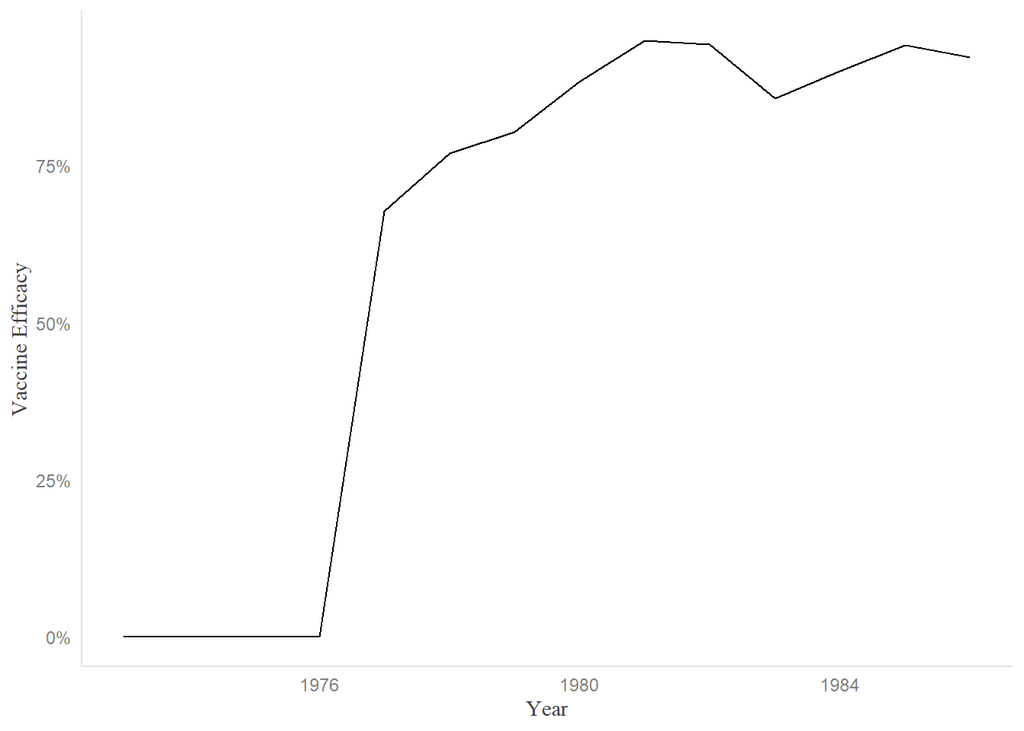

Figure 1: Measles Vaccine Efficacy over time in Germany

```r
library(scales)
measles %>%
    mutate(adjEff = case_when(Year < 1977 ~ 0
                              , TRUE ~ vacEff)) %>%
    ggplot(aes(x = Year, y = adjEff)) +
    geom_line() +
    scale_y_continuous(labels = percent_format(scale = 100)) +
    labs(y = 'Vaccine Efficacy')
```

#### Instructions:

Does your graph resemble the result from the original paper?

##### Answer:

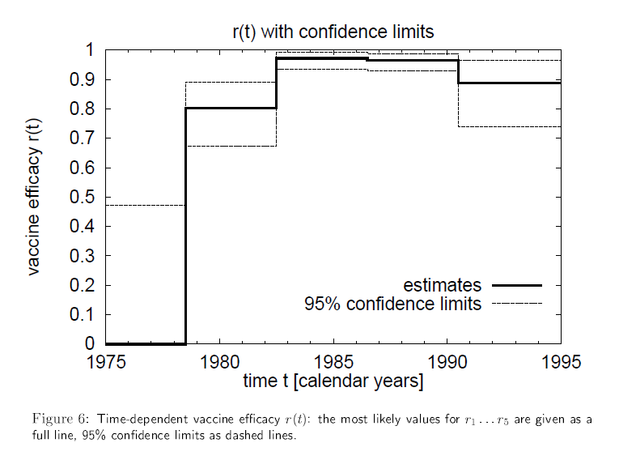

Figure 2: Eichner’s Figure 6, showing vaccine efficacy over time

#### Instructions:

Next step is to look at the differences among years and see if can say that the change between two years is significant. One way of doing this is by comparing the risk ratios by estimating confidence intervals for each year’s RR. Make calculations for all years and compare RR and their CI with each other. If the CI for an RR does not overlap the RR for another year, then the two RR values can be regarded as significantly different. Make comparisons between all adjacent years.

The course literature referred to a site where one can manually enter data into 2X2 contingency tables to find confidence intervals for risk ratios, but this seemed rather inefficient if one has many datasets to compare. Thus, I did some internet digging to figure out how to calculate the confidence interval myself and do the same work programmatically. I found a discussion on Stack Exchange (Reference 4) that gave a formula for calculating the standard error of a risk ratio, as well as how to use this to derive the 95% confidence interval. I confirmed that my values matched the reference provided by the course literature (Reference 5).

```r
measles %<>%
    mutate(
        seRiskRatio = sqrt((1 / obsVac) - (1 / (nVac)) +  (1 / obsUnvac) - (1 / (nUnvac)))
        , riskRatioLoCI = exp(log(riskRatio) - 1.96 * seRiskRatio)
        , riskRatioHiCI = exp(log(riskRatio) + 1.96 * seRiskRatio)
    )

measles
```

```
## # A tibble: 14 x 18
##     Year pCentCvg     n obsUnvac obsVac  nVac nUnvac riskVac riskUnvac oddsVac
##    <int>    <dbl> <dbl>    <dbl>  <dbl> <dbl>  <dbl>   <dbl>     <dbl>   <dbl>
##  1  1973     45.1  1253        3      2   565    688 0.00354   0.00436 0.00355
##  2  1974     27.6  1509        3      2   416   1093 0.00481   0.00274 0.00483
##  3  1975     42.4  1548        9      7   656    892 0.0107    0.0101  0.0108
##  4  1976     35.7  1690        7      3   603   1087 0.00498   0.00644 0.005
##  5  1977     43.7  1747       20      5   763    984 0.00655   0.0203  0.00660
##  6  1978     54.2  1871       22      6  1014    857 0.00592   0.0257  0.00595
##  7  1979     67.7  1810       17      7  1225    585 0.00571   0.0291  0.00575
##  8  1980     66.8  1903       17      4  1271    632 0.00315   0.0269  0.00316
##  9  1981     72.6  2027       22      3  1472    555 0.00204   0.0396  0.00204
## 10  1982     74.3  2020       24      4  1501    519 0.00266   0.0462  0.00267
## 11  1983     73.7  2076       15      6  1530    546 0.00392   0.0275  0.00394
## 12  1984     79.6  2081       18      7  1656    425 0.00423   0.0424  0.00424
## 13  1985     83.7  2089       20      6  1748    341 0.00343   0.0587  0.00344
## 14  1986     85    2147       16      7  1825    322 0.00384   0.0497  0.00385
## # ... with 8 more variables: oddsUnvac <dbl>, riskRatio <dbl>, vacEff <dbl>,
## #   healthyUnvac <dbl>, healthyVac <dbl>, seRiskRatio <dbl>,
## #   riskRatioLoCI <dbl>, riskRatioHiCI <dbl>
```

#### Instructions:

Are there any significant shifts in vaccination efficacy over time?

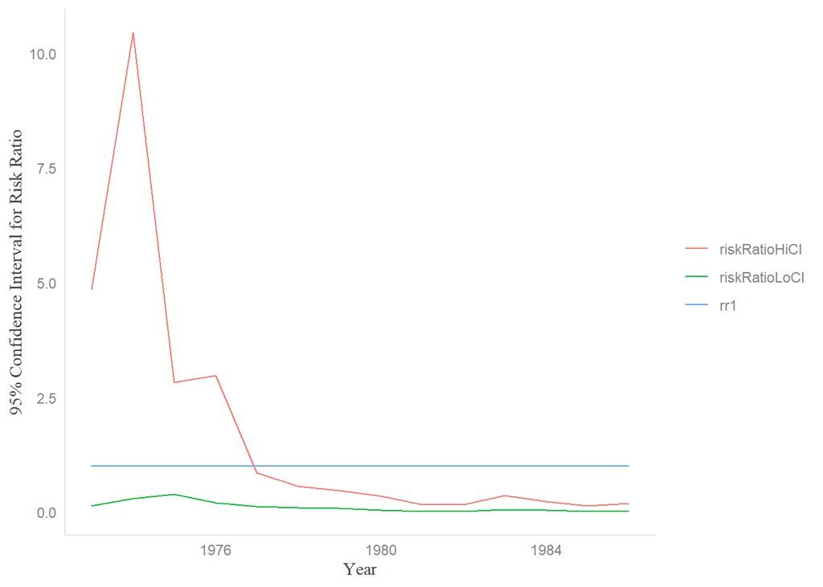

Figure 3: 95% Confidence Intervals for the Risk Ratio Over Time

```r
measles %>%
    select(Year, riskRatioLoCI, riskRatioHiCI) %>%
    mutate(rr1 = 1) %>%
    pivot_longer(cols = c(riskRatioLoCI, riskRatioHiCI, rr1)) %>%
        ggplot(aes(x = Year, y = value, color = name)) +
        geom_line() +
        labs(y = '95% Confidence Interval for Risk Ratio')
```

##### Answer:

There was never a two-year period where the confidence intervals did not overlap. Even in the year with the greatest improvement in vaccine efficacy (and reduction in risk ratio for those who were vaccinated), the 95% CI for the risk ratio in 1976 was 0.20–2.98 and in 1977 it was 0.12–0.86.

#### Instructions:

Once you have both the RR and its CI you will also be able to calculate CI for each value of vaccine efficacy. You can then produce a graph with both vaccine efficacy and its CI if you add two columns one for +CL for vaccine efficacy (Confidence Limit) and one for -CL for vaccine efficacy.

```r
measles %<>%
    mutate(
        vacEffLoCI = 1 - riskRatioHiCI
        , vacEffHiCI = 1 - riskRatioLoCI
    )

measles
```

```
## # A tibble: 14 x 20
##     Year pCentCvg     n obsUnvac obsVac  nVac nUnvac riskVac riskUnvac oddsVac
##    <int>    <dbl> <dbl>    <dbl>  <dbl> <dbl>  <dbl>   <dbl>     <dbl>   <dbl>
##  1  1973     45.1  1253        3      2   565    688 0.00354   0.00436 0.00355
##  2  1974     27.6  1509        3      2   416   1093 0.00481   0.00274 0.00483
##  3  1975     42.4  1548        9      7   656    892 0.0107    0.0101  0.0108
##  4  1976     35.7  1690        7      3   603   1087 0.00498   0.00644 0.005
##  5  1977     43.7  1747       20      5   763    984 0.00655   0.0203  0.00660
##  6  1978     54.2  1871       22      6  1014    857 0.00592   0.0257  0.00595
##  7  1979     67.7  1810       17      7  1225    585 0.00571   0.0291  0.00575
##  8  1980     66.8  1903       17      4  1271    632 0.00315   0.0269  0.00316
##  9  1981     72.6  2027       22      3  1472    555 0.00204   0.0396  0.00204
## 10  1982     74.3  2020       24      4  1501    519 0.00266   0.0462  0.00267
## 11  1983     73.7  2076       15      6  1530    546 0.00392   0.0275  0.00394
## 12  1984     79.6  2081       18      7  1656    425 0.00423   0.0424  0.00424
## 13  1985     83.7  2089       20      6  1748    341 0.00343   0.0587  0.00344
## 14  1986     85    2147       16      7  1825    322 0.00384   0.0497  0.00385
## # ... with 10 more variables: oddsUnvac <dbl>, riskRatio <dbl>, vacEff <dbl>,
## #   healthyUnvac <dbl>, healthyVac <dbl>, seRiskRatio <dbl>,
## #   riskRatioLoCI <dbl>, riskRatioHiCI <dbl>, vacEffLoCI <dbl>,
## #   vacEffHiCI <dbl>
```

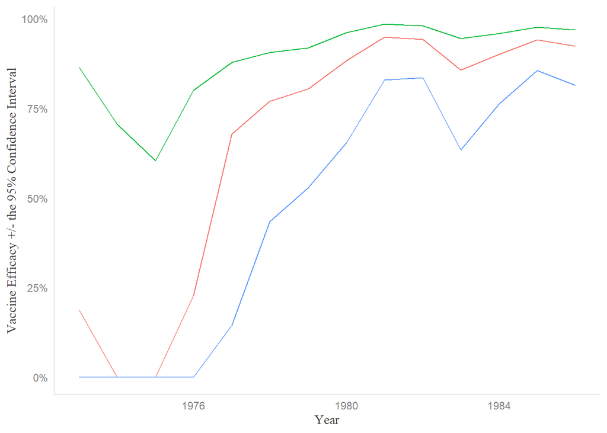

Figure 4: 95% Confidence Intervals for the Vaccine Efficacy Over Time

```r
measles %>%
    select(Year, vacEff, vacEffLoCI, vacEffHiCI) %>%
    mutate(rr1 = 1) %>%
    pivot_longer(cols = c(vacEff, vacEffLoCI, vacEffHiCI)) %>%
    mutate(value = case_when(value < 0 ~ 0, TRUE ~ value)) %>%
        ggplot(aes(x = Year, y = value, color = name)) +
        geom_line() +
        labs(y = 'Vaccine Efficacy +/- the 95% Confidence Interval') +
        scale_y_continuous(labels = percent_format(scale = 100)) +
    theme(legend.position = 'none')
```

## Discussion

The measles vaccine did not show efficacy in the first couple of years, however these years were characterized by low incidence of measles cases in the cohorts studied. From year 1977 onwards, however, there was a demonstrable (i.e., statistically significant) effect of the measles vaccine in reducing the risk of developing measles. The risk ratio for developing ratio remained low throughout the rest of the study period.

## References

1. Eichner, Martin. Estimation of the time-dependent vaccine efficacy from a measles epidemic. Statistics in Medicine (2001).
2. [Fisher’s or chi-square test?](https://www.graphpad.com/guides/prism/latest/statistics/stat_chi-square_or_fishers_test.htm)
3. [Educational Research Column: Choosing Wisely: Chi-Square vs. Fisher’s Exact](https://www.saem.org/about-saem/academies-interest-groups-affiliates2/cdem/for-students/cdem-voice/educational-research-column/educational-research-column-choosing-wisely-chi-square-vs.-fisher-s-exact)
4. [Stack Exchange: Formula for standard error of Risk Ratios and calculationg 95% Confidence Intervals](https://stats.stackexchange.com/questions/126727/why-doesnt-standard-error-for-ratios-have-log-in-it)
5. [Open Epi 2X2 Table Statistics](http://www.openepi.com/TwobyTwo/TwobyTwo.htm)